# Анализ продаж пиццерии

Данные взяты с платформы Kaggle (https://www.kaggle.com/datasets/shilongzhuang/pizza-sales). Они включают в себя основные характеристики заказов пиццерии Plato's Pizza в Нью-Джерси за период с 1 января по 31 декабря 2015 года.

```python
import numpy as np
import pandas as pd
import matplotlib.pyplot as plt
import seaborn as sns
sns.set(rc={"figure.figsize":(10,7)})
sns.set_style("whitegrid")
```

```python
data = pd.read_excel("https://github.com/VladislavOvechkin/Pizza_Restaurant_Sales_Analysis/raw/main/Data%20Model%20-%20Pizza%20Sales.xlsx")
```

```python
data.head()
```

|  | order_details_id | order_id | pizza_id | quantity | order_date | order_time | unit_price | total_price | pizza_size | pizza_category | pizza_ingredients | pizza_name |
| --- | --- | --- | --- | --- | --- | --- | --- | --- | --- | --- | --- | --- |
| 0 | 1 | 1 | hawaiian_m | 1 | 2015-01-01 | 11:38:36 | 13.25 | 13.25 | M | Classic | Sliced Ham, Pineapple, Mozzarella Cheese | The Hawaiian Pizza |
| 1 | 2 | 2 | classic_dlx_m | 1 | 2015-01-01 | 11:57:40 | 16.00 | 16.00 | M | Classic | Pepperoni, Mushrooms, Red Onions, Red Peppers,... | The Classic Deluxe Pizza |
| 2 | 3 | 2 | five_cheese_l | 1 | 2015-01-01 | 11:57:40 | 18.50 | 18.50 | L | Veggie | Mozzarella Cheese, Provolone Cheese, Smoked Go... | The Five Cheese Pizza |
| 3 | 4 | 2 | ital_supr_l | 1 | 2015-01-01 | 11:57:40 | 20.75 | 20.75 | L | Supreme | Calabrese Salami, Capocollo, Tomatoes, Red Oni... | The Italian Supreme Pizza |
| 4 | 5 | 2 | mexicana_m | 1 | 2015-01-01 | 11:57:40 | 16.00 | 16.00 | M | Veggie | Tomatoes, Red Peppers, Jalapeno Peppers, Red O... | The Mexicana Pizza |

### Анализ содержания меню пиццерии

Для начала рассмотрим основные характеристики позиций, предлагаемых в пиццерии.

```python
data.pizza_name.nunique()
```

```
32
```

```python
data.pizza_name.unique()
```

```
array(['The Hawaiian Pizza', 'The Classic Deluxe Pizza',
       'The Five Cheese Pizza', 'The Italian Supreme Pizza',
       'The Mexicana Pizza', 'The Thai Chicken Pizza',
       'The Prosciutto and Arugula Pizza', 'The Barbecue Chicken Pizza',
       'The Greek Pizza', 'The Spinach Supreme Pizza',
       'The Green Garden Pizza', 'The Italian Capocollo Pizza',
       'The Spicy Italian Pizza', 'The Spinach Pesto Pizza',
       'The Vegetables + Vegetables Pizza', 'The Southwest Chicken Pizza',
       'The California Chicken Pizza', 'The Pepperoni Pizza',
       'The Chicken Pesto Pizza', 'The Big Meat Pizza',
       'The Soppressata Pizza', 'The Four Cheese Pizza',
       'The Napolitana Pizza', 'The Calabrese Pizza',
       'The Italian Vegetables Pizza', 'The Mediterranean Pizza',
       'The Pepper Salami Pizza', 'The Spinach and Feta Pizza',
       'The Sicilian Pizza', 'The Chicken Alfredo Pizza',
       'The Pepperoni, Mushroom, and Peppers Pizza',
       'The Brie Carre Pizza'], dtype=object)
```

```python
data.pizza_size.nunique()
```

```
5
```

```python
data.pizza_size.unique()
```

```
array(['M', 'L', 'S', 'XL', 'XXL'], dtype=object)
```

В ресторане готовят 32 различных вида пицц 5 разных размеров (Стоит сразу оговориться, что, возможно, в меню пиццерии есть пиццы, которые не были заказаны ни разу и, соотвественно, информации о них нет в данном датасете.).

```python
data.pizza_category.nunique()
```

```
4
```

```python
data.pizza_category.unique()
```

```
array(['Classic', 'Veggie', 'Supreme', 'Chicken'], dtype=object)
```

Каждая пицца может быть отнесена к одной из 4 категорий: классическая пицца, вегетарианская, высшего качества, куриная.

```python
data.groupby("pizza_category")["pizza_name"].nunique()/data.pizza_name.nunique()
```

```
pizza_category
Chicken    0.18750
Classic    0.25000
Supreme    0.28125
Veggie     0.28125
Name: pizza_name, dtype: float64
```

```python
data.unit_price.mean()
```

```
16.494132044426006
```

```python
data.groupby("pizza_category")["unit_price"].mean()
```

```
pizza_category
Chicken    17.709408
Classic    14.797490
Supreme    17.363229
Veggie     16.612639
Name: unit_price, dtype: float64
```

Средняя цена всех пицц в пиццерии составляет 16.5 долларов. "Классические" пиццы стоят дешевле - в среднем 14.8 долларов за пиццу. Пиццы, относящиеся к категориям "куриные" и "высшего качества", стоят в среднем больше 17 долларов. Ниже можно также увидеть как различаются цены пицц в каждой категории в зависимости от размера.

```python
data.groupby(["pizza_category", "pizza_size"])["unit_price"].mean()
```

```
pizza_category  pizza_size
Chicken         L             20.750000
                M             16.750000
                S             12.750000
Classic         L             18.376850
                M             14.739122
                S             11.375021
                XL            25.500000
                XXL           35.950000
Supreme         L             20.652837
                M             16.429972
                S             14.048149
Veggie          L             19.295383
                M             15.938485
                S             12.161352
Name: unit_price, dtype: float64
```

### Анализ продаж пиццерии

Наибольшей популярностью в заведении пользуется пицца под названием "Classic Deluxe Pizza". 5 процентов всех заказов пиццерии приходится на эту пиццу. Однако большой популарностью пользуются также такие пиццы, как "The Barbecue Chicken Pizza", "The Hawaiian Pizza", "The Pepperoni Pizza", "The Thai Chicken Pizza" и "The California Chicken Pizza". Самая непопулярная пицца - "The Brie Carre Pizza".

```python
data["pizza_name"].value_counts(normalize=True)
```

```
The Classic Deluxe Pizza                      0.049691
The Barbecue Chicken Pizza                    0.048787
The Hawaiian Pizza                            0.048745
The Pepperoni Pizza                           0.048725
The Thai Chicken Pizza                        0.047614
The California Chicken Pizza                  0.047347
The Sicilian Pizza                            0.038811
The Spicy Italian Pizza                       0.038811
The Southwest Chicken Pizza                   0.038770
The Four Cheese Pizza                         0.038050
The Italian Supreme Pizza                     0.038030
The Big Meat Pizza                            0.037248
The Vegetables + Vegetables Pizza             0.031057
The Mexicana Pizza                            0.029947
The Napolitana Pizza                          0.029844
The Spinach and Feta Pizza                    0.029453
The Prosciutto and Arugula Pizza              0.029371
The Pepper Salami Pizza                       0.029247
The Italian Capocollo Pizza                   0.029083
The Greek Pizza                               0.028918
The Five Cheese Pizza                         0.027951
The Pepperoni, Mushroom, and Peppers Pizza    0.027602
The Green Garden Pizza                        0.020300
The Chicken Alfredo Pizza                     0.020156
The Italian Vegetables Pizza                  0.020053
The Chicken Pesto Pizza                       0.019766
The Spinach Pesto Pizza                       0.019683
The Soppressata Pizza                         0.019683
The Spinach Supreme Pizza                     0.019334
The Calabrese Pizza                           0.019066
The Mediterranean Pizza                       0.018984
The Brie Carre Pizza                          0.009872
Name: pizza_name, dtype: float64
```

Рассмотрим распределение количества заказанных пицц за год в зависимости от категории пиццы и размера.

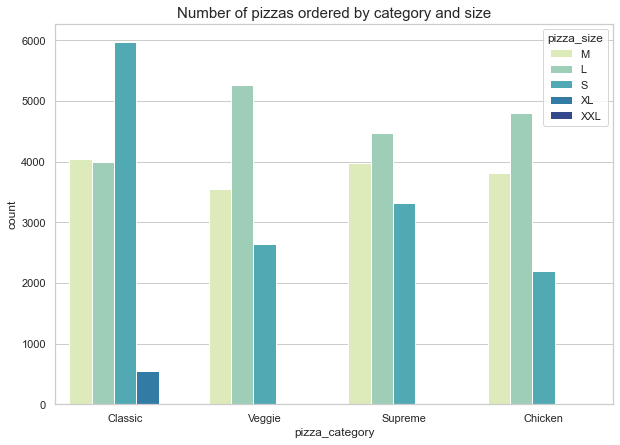

```python
sns.countplot(data, x = "pizza_category", hue = "pizza_size", palette = "YlGnBu")
plt.title("Number of pizzas ordered by category and size", fontsize = 15)
plt.show()
```

Чаще всего посетители заказывают классические пиццы маленького размера. Если же мы посмотрим на другие категории пицц, то в каждой из категорий посетители чаще заказывают пиццы размеров "М" и "L". Пиццы размеров "XL" и "XLL" (судя по данным, в пиццерии готовят только классические пиццы подобных размеров) оказались совсем непопулярны среди посетителей, заказы таких пицц составляют крайне малую долю.

```python
data[(data.pizza_size == "S") & (data.pizza_category == "Classic")]["unit_price"].mean()
```

```
11.375020920502092
```

Возможно, одна из причин популярности "классических" пицц маленького размера - их низкая стоимость.

```python
data[(data.pizza_size == "XL") | (data.pizza_size == "XXL")]["total_price"].sum()/ data["total_price"].sum()
```

```
0.018441541434870184
```

```python
data[data.pizza_size == "XXL"]["total_price"].sum()/ data["total_price"].sum()
```

```
0.0012307729176892798
```

Продажи пицц размеров "XL" и "XXL" приносят пиццерии меньше 2 процентов выручки, в том числе продажи пицц размера "XXL" формируют всего 0.12 процентов выручки.

Если смотреть на распределение заказанных пицц только по размеру, то можно увидеть, что чаще всего посетители заказывают пиццы размера L.

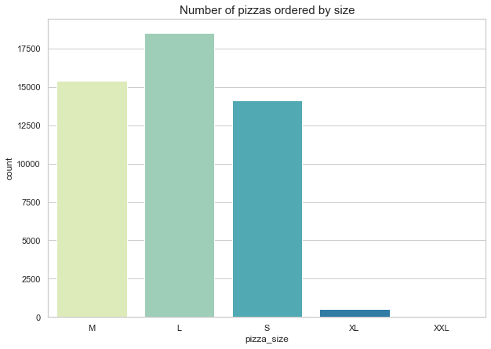

```python
sns.countplot(data, x = "pizza_size", palette = "YlGnBu")
plt.title("Number of pizzas ordered by size", fontsize = 15)
plt.show()
```

Посмотрим на распределение количества заказанных пицц по всем дням в 2015 году.

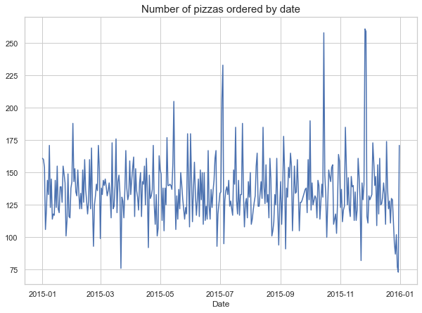

```python
sns.lineplot(x = data.order_date.unique(), y = data.groupby("order_date")["pizza_name"].count().values)
plt.title("Number of pizzas ordered by date", fontsize = 15)
plt.xlabel("Date")
plt.show()
```

```python
data.groupby("order_date")["pizza_name"].count().sort_values(ascending = False).head(10)
```

```
order_date
2015-11-26    261
2015-11-27    259
2015-10-15    258
2015-07-04    233
2015-07-03    207
2015-05-15    205
2015-10-01    190
2015-07-24    188
2015-02-01    188
2015-11-06    185
Name: pizza_name, dtype: int64
```

Больше всего пицц было заказано 26 и 27 ноября. В эти дни в США был день благодарения. Много пицц так же было заказано 3 и 4 июля, в эти дни в Америке празднуют день независимости.

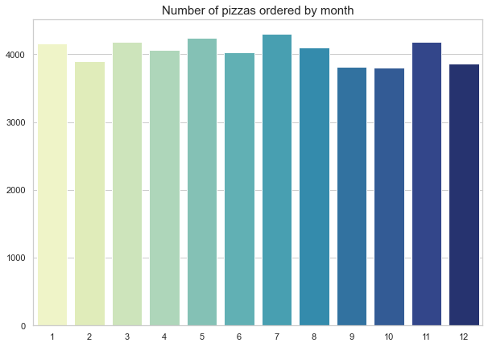

```python
sns.barplot(data, x = data.order_date.dt.month.unique(), y = data.groupby(data.order_date.dt.month)["pizza_name"].count().values, palette = "YlGnBu")
plt.title("Number of pizzas ordered by month", fontsize = 15)
plt.show()
```

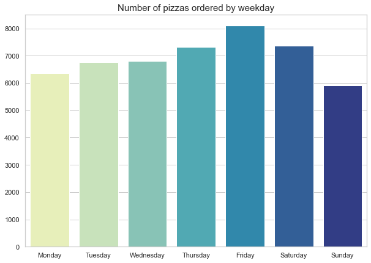

```python
sns.barplot(data, x = ["Monday", "Tuesday", "Wednesday", "Thursday", "Friday", "Saturday", "Sunday"], y = data.groupby(data.order_date.dt.weekday)["pizza_name"].count().values, palette = "YlGnBu")
plt.title("Number of pizzas ordered by weekday", fontsize = 15)
plt.show()
```

С точки зренения дней недели, чаще всего пиццу заказывают по четвергам, пятницам и субботам, что довольно логично, так как именно в эти дни у людей есть время отдохнуть, провести время в компании с друзьями, коллегами или семьей.

```python
order_time_hour = []
for i in range(len(data)):
    order_time_hour.append(data["order_time"].values[i].hour)
```

```python
data["order_time_hour"] = order_time_hour
```

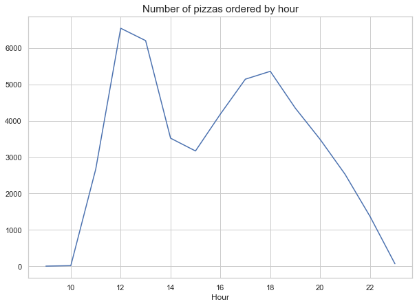

```python
sns.lineplot(x = sorted(data.order_time_hour.unique()), y = data.groupby("order_time_hour")["pizza_name"].count().values)
plt.title("Number of pizzas ordered by hour", fontsize = 15)
plt.xlabel("Hour")
plt.show()
```

Если смотреть распределение числа заказанных пицц по времени заказа, то больше всего заказов приходится на период с 12 до 13 часов дня, а также на 17-18 часов вечера.

```python
orders_by_time = pd.DataFrame(data.groupby(["order_time_hour", "order_id"])["pizza_name"].count())
```

```python
orders_by_time.groupby("order_time_hour")["pizza_name"].count()
```

```
order_time_hour
9        1
10       8
11    1231
12    2520
13    2455
14    1472
15    1468
16    1920
17    2336
18    2399
19    2009
20    1642
21    1198
22     663
23      28
Name: pizza_name, dtype: int64
```

```python
data.groupby("order_id")["total_price"].sum().mean()
```

```
38.30726229508162
```

Средний чек в пиццерии равен 38.3 долларов.

```python
data.groupby("order_id")["total_price"].sum().max()
```

```
444.2
```

Максимальный чек за 2015 год составил 444.2 доллара.

```python
data.groupby("order_id")["total_price"].sum().min()
```

```
9.75
```

Минимальная стоимость заказана равна 9.75 долларов.

Ниже представлено распределение заказов по их стоимости. Как видно из гистораммы, больше всего заказов - это заказы на небольшие суммы, до 25 долларов. Значительную долю заказов составляют так же заказы стоимостью от 25 до 50 долларов.

```python
orders_prices = data.groupby("order_id")["total_price"].sum()
```

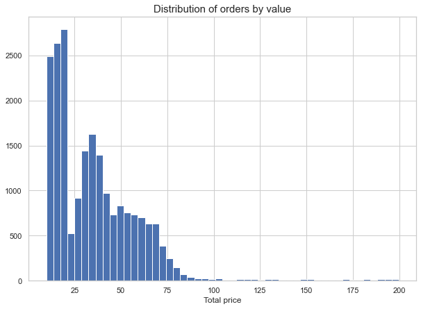

```python
orders_prices[orders_prices < 200].hist(bins=50)
plt.title("Distribution of orders by value", fontsize = 15)
plt.xlabel("Total price")
plt.show()
```

```python
orders_prices[orders_prices < 25].count()
```

```
8441
```

```python
orders_prices[(orders_prices > 25) & (orders_prices < 50)].count()
```

```
7615
```

```python
orders_prices[orders_prices > 50].count()
```

```
5204
```

```python
orders_prices[orders_prices < 50].count()/len(orders_prices)
```

```
0.7540983606557377
```

Несмотря на то, что заказы до 50 долларов составляют 75 процентов от всех заказов, они приносят чуть больше половины выручки пиццерии. Более 48 процентов выручки приносят заказы стоимостью более 50 долларов, составляя при этом долю в менее чем 25 процентов от всех заказов.

```python
orders_prices[orders_prices < 50].sum()/orders_prices.sum()
```

```
0.5129300544757016
```

```python
orders_prices[orders_prices > 50].sum()/orders_prices.sum()
```

```
0.4842577284463278
```

Рассмотрим, какие ингредиенты встречаются в тех пиццах, которые посетители заказывают чаще всего.

```python
all_ingredients = []

for ingrds in data["pizza_ingredients"]:
    for i in ingrds.split(","):
        all_ingredients.append(i)
```

```python
from wordcloud import WordCloud
```

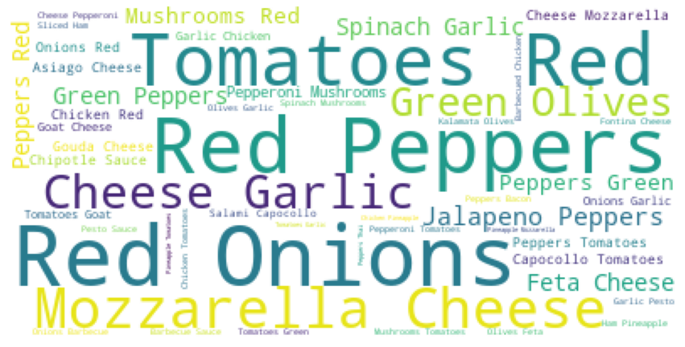

```python
wordcloud = WordCloud(max_font_size=50, max_words=50, background_color="white").generate(' '.join(all_ingredients))
plt.figure(figsize =(15,10))
plt.imshow(wordcloud)
plt.axis("off")
plt.show()
```

Как мы видим, те пиццы, которые посетители пиццерии часто заказывают, включают в себя следующие ингредиенты: "Tomatoes Red", "Red Peppers", "Red Onions", "Mozzarella Cheese", "Cheese Garlic", "Green Olives", "Spinach Garlc", "Green Peppers", "Feta Cheese", "Japaleno Peppers", "Mushrooms Red". Да, такие ингредиенты, как "Tomatoes Red", "Red Peppers", "Red Onions", "Mozzarella Cheese" часто встречаются в заказанных пиццах только потому, что являются основными для многих видов пицц, однако все равно стоит учитывать предпочтения посетителей относительно других распространенных ингредиентов при разработке новых пицц для меню ресторана.

### Выводы

1. Большую часть заказов пиццерии составляют небольшие заказы стоимостью до 50 долларов. Однако такие заказы приносят только половину выручки компании, в то время как другая половина выручки формируется за счет заказов стоимостью более 50 долларов, хотя в количественном отношении таких заказов в пиццерии в 3 раза меньше, чем небольших по стоимости.
2. В среднем наиболее популярными среди посетителей являются пиццы размером "M" или "L". Однако пиццы классической категории размера "S" заказывают чаще всех остальных пицц других категории и размера. Возможно, одна из причин этого заключается в самой низкой средней цене пицц такой категории и размера по сравнению с другими вариантами. Продажи пицц размера "XXL" формируют всего 0.12 процентов выручки. Стоит подумать о возможности отказа от приготовления пицц такого размера в пользу сосредоточения усилий на приготовлении и продажах пицц размеров "M" и "L".
3. Больше всего заказов совершается в такие дни, как четверг, пятница и суббота. Можно выделить два пика наибольшего числа заказов - это время обеда (примерно с 12 до 13 часов дня) и время ужина (17-19 часов вечера). Учитывая второй вывод, стоит подумать над возможностью проведения каких-либо акций ("счастливые часы" или "пицца дня по сниженой цене") для привлечения большего числа посетителей и увеличения выручки пиццерии.
4. В процессе анализа были определены ключевые ингредиенты, которые встречаются в пиццах, пользующихся наибольшей популярностью. Необходимо учитывать предпочтения посетителей относительно ингредиентов, которые не являются базовыми для пицц (как например, "Tomatoes Red", "Red Onions", "Mozzarella Cheese"), при разработке новых пицц для меню ресторана. Одним из направлений развития может стать расширение меню и созданием альтернативных блюд (не пицц) с учетом предпочтений по ингредиентам. Такое решение способно дополнительно привлечь внимание потребителей и повысить средний чек заказа.